# Probability Distribution - Continuous

- Author: Diego Inácio
- GitHub: github.com/diegoinacio
- Notebook: distributions_continuous.ipynb

Brief overview of *continuous probability distributions*.

```python
%matplotlib inline
import matplotlib
import matplotlib.pyplot as plt

import numpy as np
import pandas as pd
```

```python
np.seterr(divide="ignore", invalid="ignore")
plt.rcParams["figure.figsize"] = (16, 8)
```

## Introduction

A **continuous probability distribution** is the probability distribution of real number variables with uncountably many possible values. It means that a random variable $X$ has a continuous distribution probability if there is a funtion $f:\mathbb{R} \rightarrow [0,\infty]$ for each interval $[a,b]\subset\mathbb{R}$.

### Probability density function

The **probability density funtion** (**PDF**) is a function whose value represents a relative likelihood that the value of the random variable would be close to that sample. To calculate $X$ belonging to the interval $[a,b]$:

$$ \large f(x) = Pr(a \leq X \leq b)=\int_a^b g(x)dx $$

### Cumulative distribution function

A **cumulative distribution function** (**CDF**) calculates the probability of a random observation being less than or equal a certain value. It can be expressed as:

$$ \large F(x)=Pr(X \leq x)=\int_{-\infty}^x f(t) dt $$

## Normal distribution

The **normal distribution** is one of the most used to model natural phenomena in general. It has as parameters $\mu$ (mean or expectation) and $\sigma$ (standard deviation) or $\sigma^2$ (variation), and its *probability density function* can be expressed as:

$$ \large f(x;\mu,\sigma^2)=\frac{1}{\sqrt{2\pi\sigma^2}} e^{-\frac{(x-\mu)^2}{2\sigma^2}}=\frac{1}{\sigma\sqrt{2\pi}} e^{-\frac{1}{2}\left(\frac{x-\mu}{\sigma}\right)^2} $$

```python
def normalDistribution(x, mu, sigma):
    norm = 1/(sigma*(2*np.pi)**0.5)
    return norm*np.exp(-1/2*((x - mu)/(sigma))**2)
```

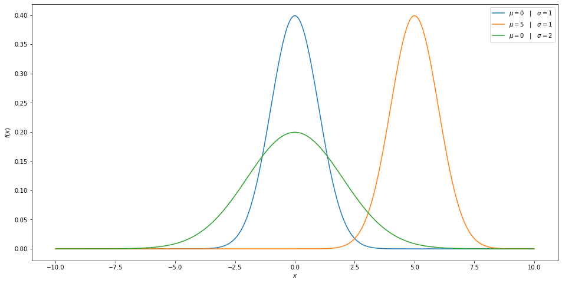

```python
x = np.linspace(-10, 10, 1000)

# Distribution A
mu, sigma = 0, 1

plt.plot(
    x, normalDistribution(x, mu, sigma),
    label=f'$\mu={mu} \\quad|\\quad \sigma={sigma}$'
)

# Distribution B
mu, sigma = 5, 1

plt.plot(
    x, normalDistribution(x, mu, sigma),
    label=f'$\mu={mu} \\quad|\\quad \sigma={sigma}$'
)

# Distribution C
mu, sigma = 0, 2

plt.plot(
    x, normalDistribution(x, mu, sigma),
    label=f'$\mu={mu} \\quad|\\quad \sigma={sigma}$'
)

# Visualization
plt.xlabel(r'$x$')
plt.ylabel(r'$f(x)$')
plt.legend()
plt.show()
```

The *cumulative distribution function* of the gaussian distribution (also denoted with $\Phi$) can be expressed as:

$$ \large \Phi(x)=\frac{1}{\sqrt{2\pi}}\int_{-\infty}^{x}e^{-\frac{t^2}{2}}dx $$$$ \large F(x;\mu,\sigma^2)=\Phi\left(\frac{x-\mu}{\sigma}\right) $$

```python
def Phi(x):
    t = x
    dt = t[1] - t[0]
    ft = np.exp(-t**2/2)
    norm = 1/((2*np.pi)**0.5)
    RANGE = np.arange(x.size) + 1
    integ = np.array([ft[:x].sum() for x in RANGE])
    return norm*integ*dt

def cumulativeNormalDistribution(x, mu, sigma):
    Phi_ = Phi((x - mu)/(sigma*2**0.5))
    return 1/2*(1 + Phi_)
```

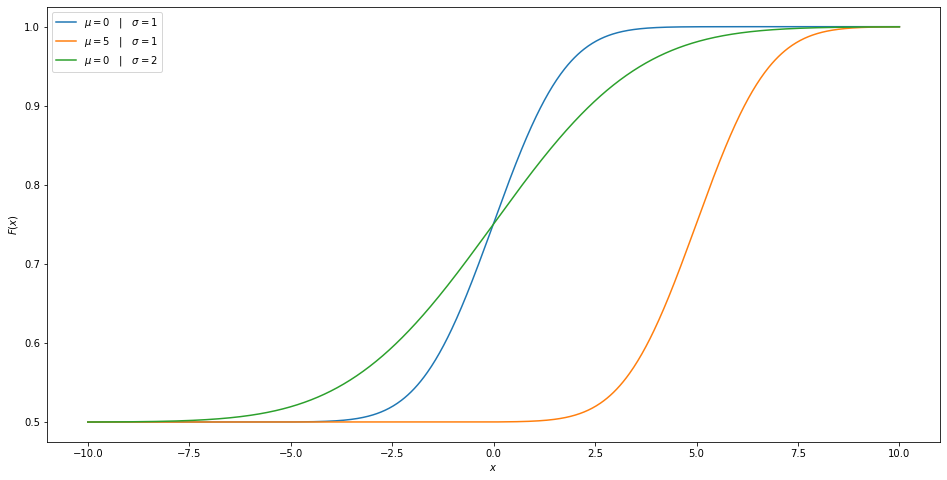

```python
x = np.linspace(-10, 10, 1000)

# Distribution A
mu, sigma = 0, 1

plt.plot(
    x, cumulativeNormalDistribution(x, mu, sigma),
    label=f'$\mu={mu} \\quad|\\quad \sigma={sigma}$'
)

# Distribution B
mu, sigma = 5, 1

plt.plot(
    x, cumulativeNormalDistribution(x, mu, sigma),
    label=f'$\mu={mu} \\quad|\\quad \sigma={sigma}$'
)

# Distribution C
mu, sigma = 0, 2

plt.plot(
    x, cumulativeNormalDistribution(x, mu, sigma),
    label=f'$\mu={mu} \\quad|\\quad \sigma={sigma}$'
)

# Visualization
plt.xlabel(r'$x$')
plt.ylabel(r'$F(x)$')
plt.legend()
plt.show()
```

## Chi-squared distribution

A **chi-squared distribution** (or $\chi^2$**-distribution**) with $k$ *degrees of freedom* represents the sum of squares of $k$ normally distributed random variables, and its probability density function can be expressed as:

$$ \large f(x;k)= \begin{cases} \frac{1}{2^{\frac{k}{2}}\Gamma\left(\frac{k}{2}\right)} x^{\frac{k}{2} - 1} e^{-\frac{x}{2}} &, x>0; \\ 0 &, \text{otherwise.} \end{cases} $$

where $\Gamma$ is the [Gamma function](https://en.wikipedia.org/wiki/Gamma_function) expressed as:

$$ \large \Gamma(s)=\int_{0}^{\infty}t^{s-1}e^{-t}dt $$

```python
def Gamma(s, infty=100, dt=1e-4):
    t = np.arange(0, infty, dt)
    s_1 = s - 1 if s >= 1 else s
    ft = t**s_1*np.exp(-t)
    return ft.sum()*dt

def chiSquaredDistribution(x, k):
    norm = 1/(2**(k/2)*Gamma(k/2))
    x_ = x**(k/2 - 1)
    e_ = np.exp(-x/2)
    return np.where(x >= 0, norm*x_*e_, 0)
```

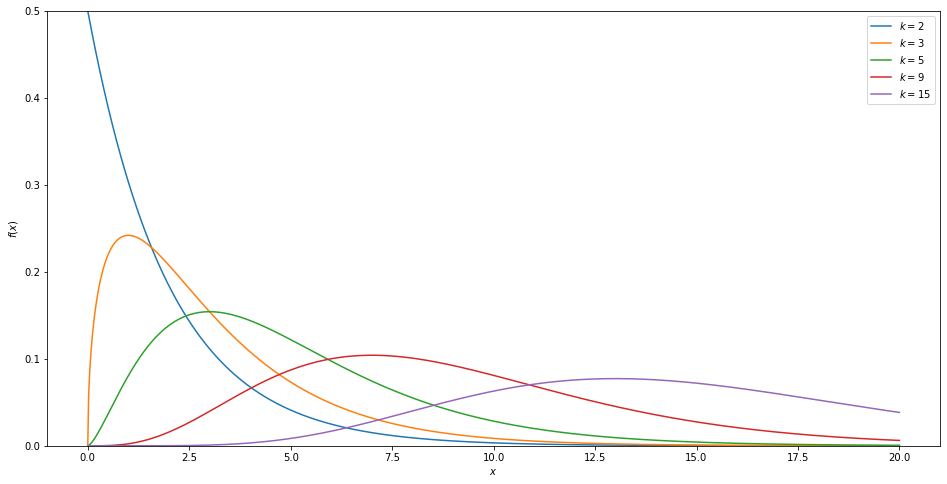

```python
x = np.linspace(0, 20, 1000)

# Distributions at k
for k in [2, 3, 5, 9, 15]:
    plt.plot(
        x, chiSquaredDistribution(x, k),
        label=f'$k={k}$'
    )

# Visualization
plt.xlabel(r'$x$')
plt.ylabel(r'$f(x)$')
plt.ylim(0, 0.5)
plt.legend()
plt.show()
```

The *cumulative distribution function* of the chi-squared distribution can be expressed as:

$$ \large F(x;k)=\frac{1}{\Gamma\left(\frac{k}{2}\right)} \gamma\left(\frac{x}{2},\frac{k}{2}\right) $$

where $\gamma$ is the [lower incomplete gamma function](https://en.wikipedia.org/wiki/Incomplete_gamma_function) expressed as:

$$ \large \gamma(x;s)=\int_{0}^{x}t^{s-1}e^{-t}dt $$

```python
def li_gamma(x, s):
    t = x
    dt = t[1] - t[0]
    ft = t**(s - 1)*np.exp(-t)
    RANGE = np.arange(x.size) + 1
    integ = np.array([ft[:x].sum() for x in RANGE])
    return integ*dt

def cumulativeChiSquaredDistribution(x, k):
    norm = 1/Gamma(k/2)
    return norm*li_gamma(x/2, k/2)
```

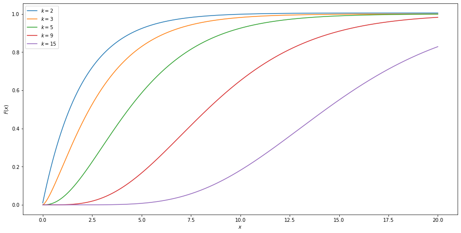

```python
x = np.linspace(0, 20, 1000)

# Distributions at k
for k in [2, 3, 5, 9, 15]:
    plt.plot(
        x, cumulativeChiSquaredDistribution(x, k),
        label=f'$k={k}$'
    )

# Visualization
plt.xlabel(r'$x$')
plt.ylabel(r'$F(x)$')

plt.legend()
plt.show()
```

## Student's t-distribution

The **student's t-distribution** is commonly used when the sample size is small and the populations's *standard deviation* is unknown, and its probability density function can be expressed as:

$$ \large f(x;v)=\frac{\Gamma\left(\frac{v+1}{2}\right)}{\sqrt{v\pi}\Gamma\left(\frac{v}{2}\right)}\left(1+\frac{x^2}{v}\right)^{-\frac{v+1}{2}} $$

where:

- $\Gamma$ is the gamma function;
- parameter $v$ is the number of *degrees of freedom*.

```python
def studentsTDistribution(x, v):
    norm = Gamma((v + 1)/2)/((v*np.pi)**0.5*Gamma(v/2))
    return norm*(1 + x**2/v)**(-(v + 1)/2)
```

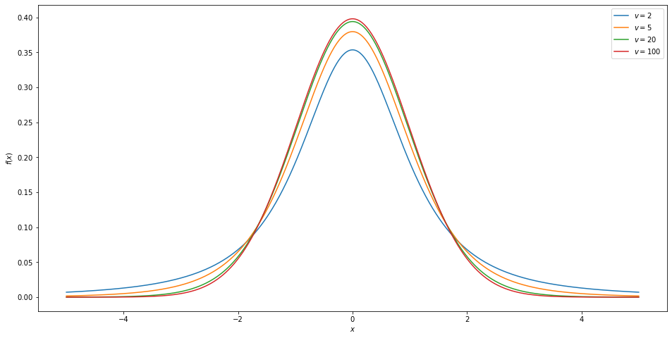

```python
x = np.linspace(-5, 5, 1000)

# Distributions at v
for v in [2, 5, 20, 100]:
    plt.plot(
        x, studentsTDistribution(x, v),
        label=f'$v={v}$'
    )

# Visualization
plt.xlabel(r'$x$')
plt.ylabel(r'$f(x)$')

plt.legend()
plt.show()
```

The *cumulative distribution function* of the students's t-distribution can be expressed as:

$$ \large F(x;v)=\frac{1}{2} + x\frac{\Gamma\left(\frac{v+1}{2}\right)}{\sqrt{v\pi}\Gamma\left(\frac{v}{2}\right)}{}_2F_1\left(\frac{1}{2},\frac{v+1}{2};\frac{3}{2};-\frac{x^2}{v}\right) $$

where ${}_2F_1$ is a particular case of the [hypergeometric function](https://en.wikipedia.org/wiki/Hypergeometric_function) defined for $|z| < 1$ by the power series:

$$ \large {}_2F_1(a,b;c;z)=\sum_{n=0}^{\infty}\frac{a^{(n)}b^{(n)}}{c^{(n)}}\frac{z^n}{n!} $$

Here $x^{(n)}$ is the [rising factorial](https://en.wikipedia.org/wiki/Falling_and_rising_factorials) defined as:

$$ \large x^{(n)}=x(x+1)(x+2)...(x+n-1)=\prod_{k=0}^{n-1}(x+k) $$

```python
def factorial(n):
    if n <= 1:
        return 1
    return np.prod(np.arange(n) + 1, dtype=np.float64)

def risingFactorial(x, n):
    RANGE = np.arange(n)
    return np.prod([x + k for k in RANGE], dtype=np.float64)

def hypergeometric(a, b, c, z, infty=50):
    f = lambda n: factorial(n)
    a_ = lambda n: risingFactorial(a, n)
    b_ = lambda n: risingFactorial(b, n)
    c_ = lambda n: risingFactorial(c, n)
    RANGE = np.arange(infty)
    ABCZN = [a_(n)*b_(n)/c_(n)*z**n/f(n) for n in RANGE]
    _2F1 = np.sum(ABCZN, axis=0)
    # Given the definition is only for |z| < 1
    # and to deal with the analytic continuation problem
    # lets use the function from scipy for a while.
    import scipy.special as sc
    return sc.hyp2f1(a, b, c, z)

def cumulativeStudentsTDistribution(x, v):
    norm = Gamma((v + 1)/2)/((v*np.pi)**0.5*Gamma(v/2))
    _2F1 = hypergeometric(1/2, (v + 1)/2, 3/2, -x**2/v)
    return 1/2 + x*norm*_2F1
```

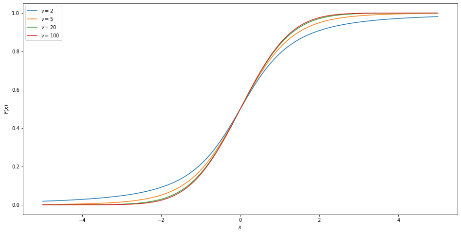

```python
x = np.linspace(-5, 5, 1000, dtype=np.float64)

# Distributions at v
for v in [2, 5, 20, 100]:
    plt.plot(
        x, cumulativeStudentsTDistribution(x, v),
        label=f'$v={v}$'
    )

# Visualization
plt.xlabel(r'$x$')
plt.ylabel(r'$F(x)$')

plt.legend()
plt.show()
```

## F-distribution

A **f-distribution** arises frequently as the null distribution of a test statistic, mostly in the *analysis of variance* (ANOVA) and other F-tests. Its *probability density function* for the degrees of freedom $d_1$ and $d_2$ can be expressed as:

$$ \large f(x;d_1,d_2)=\frac{\sqrt{\frac{(d_1x)^{d_1}d_2^{d_2}}{(d_1x+d_2)^{d_1+d_2}}}}{xB\left(\frac{d_1}{2},\frac{d_2}{2}\right)} $$

where $B$ is the [beta function](https://en.wikipedia.org/wiki/Beta_function) expressed as:

$$ \large B(z_1,z_2)=\int_0^1 t^{z_1-1}(1-t)^{z_2-1}dt $$

```python
def Beta(z1, z2, dt=1e-4):
    z1, z2 = max(z1, 0), max(z2, 0)
    t = np.linspace(0, 1, int(1/dt) + 1)
    ft = t**(z1 - 1)*(1 - t)**(z2 - 1)
    ft[~np.isfinite(ft)] = 0
    return ft.sum()*dt

def fDistribution(x, d1, d2):
    num1 = (d1*x)**d1*d2**d2
    den1 = (d1*x + d2)**(d1 + d2)
    num2 = (num1/den1)**0.5
    den2 = x*Beta(d1/2, d2/2)
    return num2/den2
```

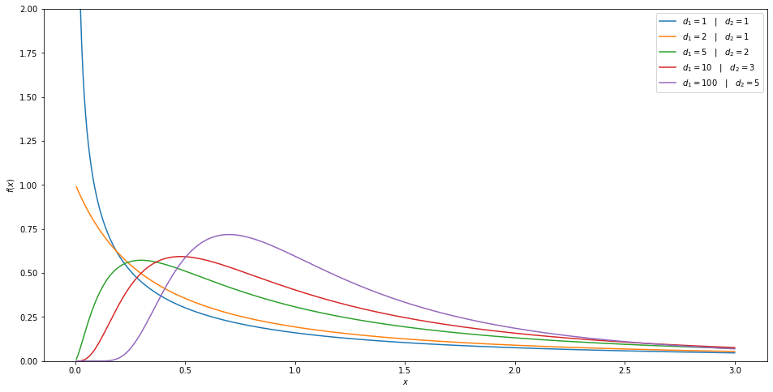

```python
x = np.linspace(0, 3, 500)

# Distributions at d1 and d2
for [d1, d2] in [(1, 1), (2, 1), (5, 2), (10, 3), (100, 5)]:
    plt.plot(
        x, fDistribution(x, d1, d2),
        label=f'$d_1={d1} \quad | \quad d_2={d2}$'
    )

# Visualization
plt.xlabel(r'$x$')
plt.ylabel(r'$f(x)$')
plt.ylim([0, 2])

plt.legend()
plt.show()
```

The *cumulative distribution function* of the f-distribution can be expressed as:

$$ \large F(x;d_1,d_2)=I_{\frac{d_1x}{d_1x+d_2}}\left(\frac{d_1}{2},\frac{d_2}{2}\right) $$

where $I_x$ is the [regularized incomplete beta function](https://en.wikipedia.org/wiki/Beta_function#Incomplete_beta_function) expressed as:

$$ \large I_x(a,b)=\frac{B(x;a,b)}{B(a,b)} $$

which is defined in terms of the **incomplete beta function** and the **complete beta function** (or simply **beta function**). The *incomplete beta function* is defined as:

$$ \large B(x;a,b)=\int_0^{x} t^{a-1}(1-t)^{b-1}dt $$

```python
def i_beta(x, a, b):
    t = x
    dt = t[1] - t[0]
    ft = t**(a - 1)*(1 - t)**(b - 1)
    ft[~np.isfinite(ft)] = 0
    RANGE = np.arange(x.size) + 1
    integ = np.array([ft[:x].sum() for x in RANGE])
    return integ*dt

def ri_beta(x, a, b):
    Ix = i_beta(x, a, b)/Beta(a, b)
    # For any reason, the incomplete beta ..
    # .. function is not working as expected.
    # Check back in the future.
    # Lets use the function from scipy for a while.
    import scipy.special as sc
    return sc.betainc(a, b, x)

def cumulativeFDistribution(x, d1, d2):
    d1d2x = d1*x/(d1*x + d2)
    return ri_beta(d1d2x, d1/2, d2/2)
```

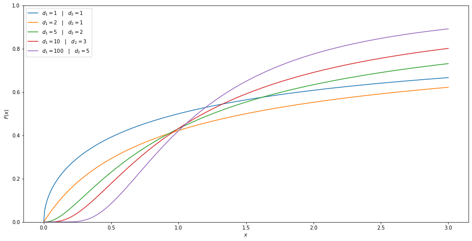

```python
x = np.linspace(0, 3, 500)

# Distributions at d1 and d2
for [d1, d2] in [(1, 1), (2, 1), (5, 2), (10, 3), (100, 5)]:
    plt.plot(
        x, cumulativeFDistribution(x, d1, d2),
        label=f'$d_1={d1} \quad | \quad d_2={d2}$'
    )

# Visualization
plt.xlabel(r'$x$')
plt.ylabel(r'$F(x)$')
plt.ylim([0, 1])

plt.legend()
plt.show()
```